# Practical Machine Learning Project

Marco Antonio Andrade Barrera

Sunday, Jun 21, 2015

This project is part of the work done for data science specialization offered on Coursera website . In particular, this work is part of the activities of the course Practical Machine Learning. The data used in this project come from this source: http://groupware.les.inf.puc-rio.br/har.

Using devices such as Jawbone Up, Nike FuelBand, and Fitbit it is now possible to collect a large amount of data about personal activity relatively inexpensively. These type of devices are part of the quantified self movement – a group of enthusiasts who take measurements about themselves regularly to improve their health, to find patterns in their behavior, or because they are tech geeks. One thing that people regularly do is quantify how much of a particular activity they do, but they rarely quantify how well they do it. In this project, the aim is to use data from accelerometers on the belt, forearm, arm, and dumbell of 6 participants. They were asked to perform barbell lifts correctly and incorrectly in 5 different ways. More information is available from the website here: http://groupware.les.inf.puc-rio.br/har.

The goal of this project is to predict the manner in which they did the exercise. This is the “classe” variable in the training set. The following code load training and testing sets. It also removes variables with NA’s and near zero variance predictors in trainings data set.

```r
library(caret)
setwd("D:/Marco/Cursos/Data Science/07 Machine learning/W3/project")
training <- read.csv("data/pml-training.csv")
testing <- read.csv("data/pml-testing.csv")

#removing vars with NA's
training <- training[,-which(apply(training,MARGIN = 2,FUN = function(c) sum(is.na(c)) != 0))]

#removing near zero variance predictors
nsv <- nearZeroVar(training, saveMetrics = T)
training <- training[, !nsv$nzv]

#removing all factors
#newTraining <- training[,-which(apply(training,MARGIN = 2,FUN = function(c) class(c)))]
```

After filtering, training data set had 19622 rows or samples and 58 posible predictors. Ideally, we should use all 58 predictor, but in order to cut down on execution time, an other filter using correlations between *classe* response and all predictors is usefull. I used predictors with correlation greater than 0.1.

```r
cor <- abs(sapply(colnames(training[, -ncol(training)]), function(x) cor(as.numeric(training[, x]), as.numeric(training$classe), method = "spearman")))

training <- training[,-1]
training <- training[,c(ncol(training),which(cor>0.1))]
```

In the next chunk, I fit a model with boosting algorithm and 10-fold cross validation in a sub-sample of 10%.

```r
set.seed(5)
modFit <- train(classe~.,method = "gbm", verbose=F, data=training[sample(1:nrow(training),trunc(0.1*nrow(training))),], trControl = trainControl(method = "cv",number = 10))
modFit
```

```
## Stochastic Gradient Boosting
##
## 1962 samples
##   22 predictor
##    5 classes: 'A', 'B', 'C', 'D', 'E'
##
## No pre-processing
## Resampling: Cross-Validated (10 fold)
##
## Summary of sample sizes: 1765, 1766, 1767, 1766, 1767, 1765, ...
##
## Resampling results across tuning parameters:
##
##   interaction.depth  n.trees  Accuracy   Kappa      Accuracy SD
##   1                   50      0.6717619  0.5828082  0.03452701
##   1                  100      0.7405650  0.6714011  0.02686803
##   1                  150      0.7797889  0.7214015  0.03020670
##   2                   50      0.8185546  0.7705748  0.02921997
##   2                  100      0.8883521  0.8589571  0.01527051
##   2                  150      0.9225129  0.9021692  0.01767985
##   3                   50      0.8858296  0.8557401  0.02079676
##   3                  100      0.9357602  0.9188850  0.01619114
##   3                  150      0.9541174  0.9420881  0.01461131
##   Kappa SD
##   0.04400384
##   0.03422299
##   0.03844151
##   0.03703784
##   0.01934197
##   0.02233062
##   0.02637901
##   0.02049748
##   0.01847779
##
## Tuning parameter 'shrinkage' was held constant at a value of 0.1
##
## Tuning parameter 'n.minobsinnode' was held constant at a value of 10
## Accuracy was used to select the optimal model using  the largest value.
## The final values used for the model were n.trees = 150,
##  interaction.depth = 3, shrinkage = 0.1 and n.minobsinnode = 10.
```

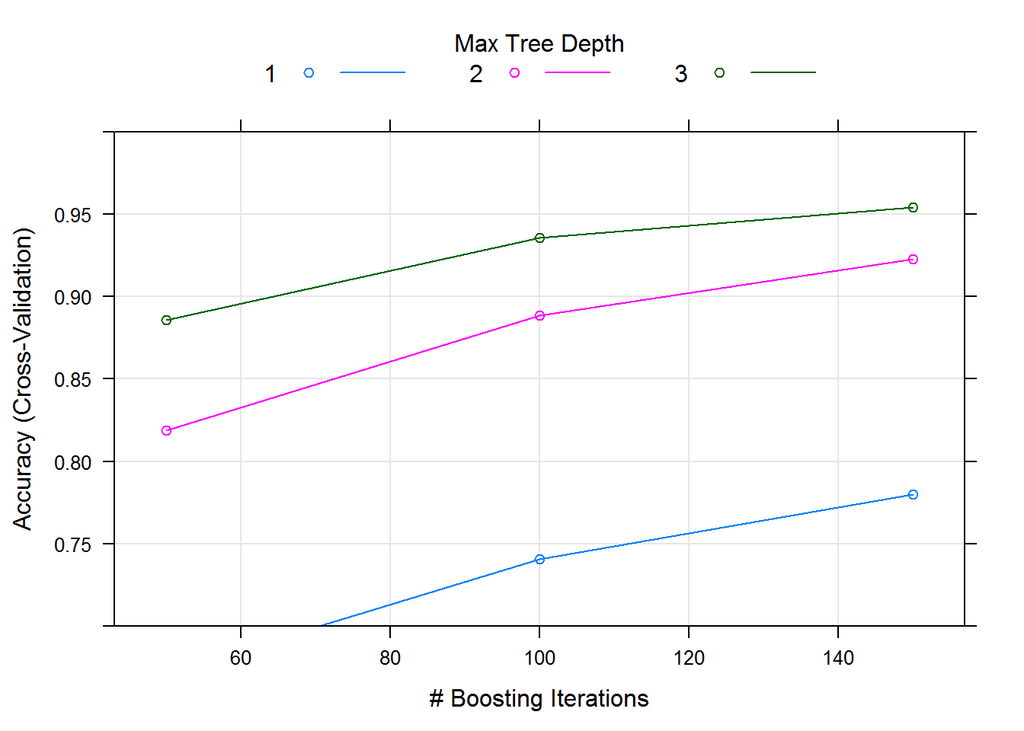

```r
plot(modFit, ylim = c(0.7, 1))
```

In the next code, a random forest model is fitting in a subsample of 10%.

```r
set.seed(5)
rfFit <- train(classe ~ ., method = "rf", data = training[sample(1:nrow(training),trunc(0.1*nrow(training))),], importance = T, trControl = trainControl(method = "cv", number = 10, verboseIter = F))
rfFit
```

```
## Random Forest
##
## 1962 samples
##   22 predictor
##    5 classes: 'A', 'B', 'C', 'D', 'E'
##
## No pre-processing
## Resampling: Cross-Validated (10 fold)
##
## Summary of sample sizes: 1765, 1766, 1767, 1766, 1767, 1765, ...
##
## Resampling results across tuning parameters:
##
##   mtry  Accuracy   Kappa      Accuracy SD  Kappa SD
##    2    0.9301765  0.9118016  0.013605945  0.01719817
##   14    0.9622937  0.9523898  0.008976039  0.01134046
##   26    0.9643190  0.9549495  0.011489661  0.01452965
##
## Accuracy was used to select the optimal model using  the largest value.
## The final value used for the model was mtry = 26.
```

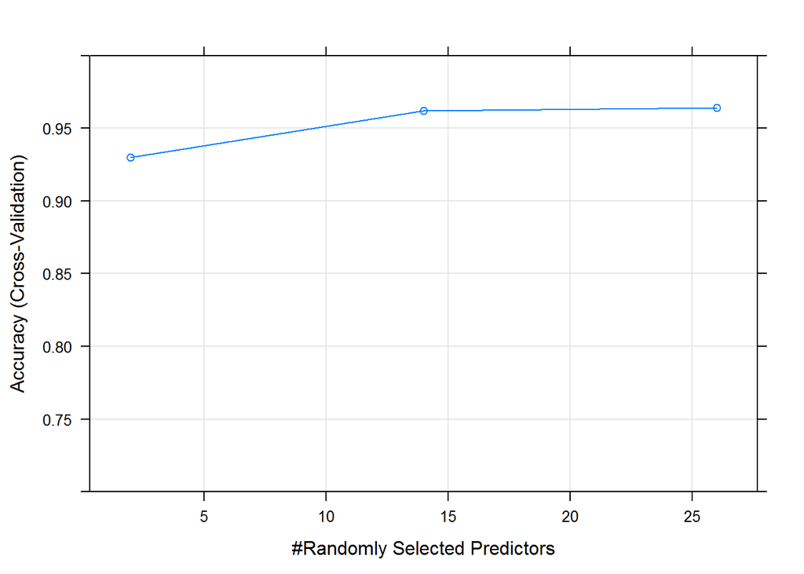

```r
plot(rfFit, ylim = c(0.7, 1))
```

Based on the abode graphics, both models have similar accuracy, where random forest being little better. The following chunks makes the estimations of 20 samples in the testing set.

```r
prediction <- as.character(predict(modFit, testing))
prediction
```

```
##  [1] "B" "A" "B" "A" "A" "E" "D" "B" "A" "A" "B" "C" "B" "A" "E" "E" "A"
## [18] "B" "B" "B"
```

```r
# write prediction files
pml_write_files = function(x){
  n = length(x)
  for(i in 1:n){
    filename = paste0("./prediction/problem_id_", i, ".txt")
    write.table(x[i], file = filename, quote = FALSE, row.names = FALSE, col.names = FALSE)
  }
}
pml_write_files(prediction)
```